# Практична робота №7

## Тема. Найпростіший потік подій. Елементи теорії СМО. Ланцюги Маркова.

## Мета: набути практичних навичок у розв’язанні задач щодо випадкових процесів, СМО та ланцюгів Маркова.

## 1. Побудувати граф станів СМО «n -клієнтів –Web-сервер» (система М/М/1) і систему рівнянь Колмогорова для 𝑛 = 3, 𝜆 = 1 𝜇 = 2. Знайти 𝑃зан, P0, 𝐴, 𝑤, 𝑇обс, 𝑇відг.

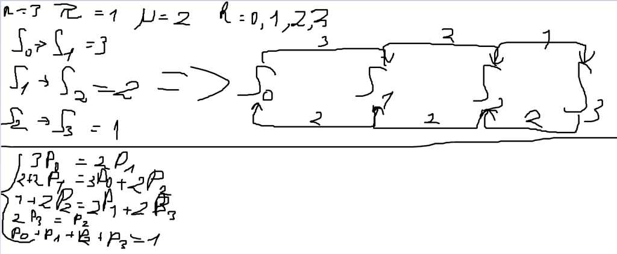

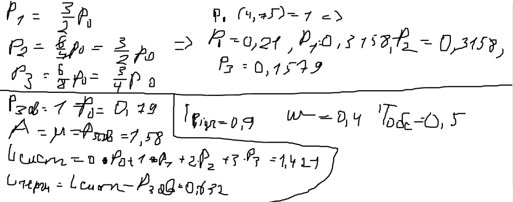

## 2. Задано матрицю переходу 𝑃1 = (0.3 0.7 0.5 0.5). Знайти матрицю переходу 𝑃3.

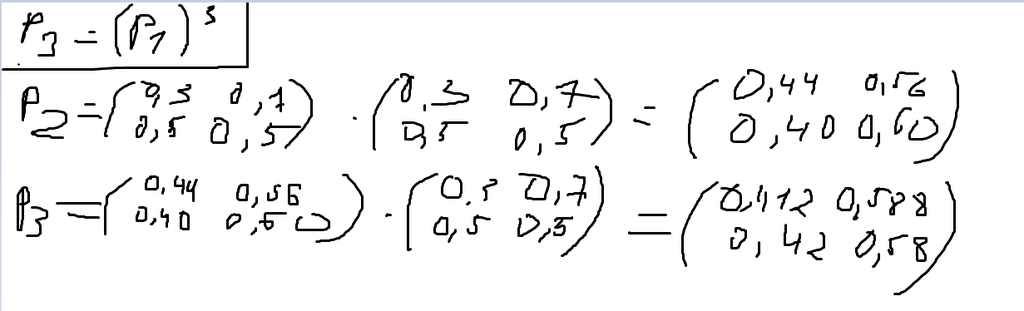

## Контрольні питання

### 1. Система Масового Обслуговування - математична модель, яка використовується для вивчення процесів, пов'язаних із надходженням заявок на обслуговування та їх виконанням. В її структурі виділяють три ключові елементи: вхідний потік (заявки, що надходять), обслуговуючі пристрої (канали, що виконують роботу) та чергу (місце очікування, якщо всі канали зайняті).

### 2. Найпростіший потік подій або потік Пуассона має три ключові властивості: стаціонарність (середня інтенсивність не змінюється з часом), ординарність (ймовірність одночасної появи двох чи більше подій за нескінченно малий інтервал часу є нульовою) та відсутність післядії (події незалежні одна від одної). Його головною вимірюваною характеристикою є інтенсивність потоку (середня кількість подій за одиницю часу), а також розподіл проміжків часу між подіями, який є експоненційним.

### 3. Основні характеристики, що визначають продуктивність СМО, включають пропускну здатність (A) — середня кількість заявок, обслужених за одиницю часу, та середню кількість зайнятих каналів (коефіцієнт використання). Важливими показниками також є ймовірність відмови (Pвідм) або абсолютні втрати, які відображають частку заявок, що не були обслужені через повну зайнятість системи.

### 4. Інтенсивність потоку подій переважно залежить від кількості та стану джерел заявок: при обмеженій кількості джерел вона знижується, коли багато клієнтів вже перебувають у системі, оскільки менше джерел залишається активними. Додатково на інтенсивність впливає стаціонарність процесу (чи є інтенсивність сталою чи змінюється залежно від часу доби/сезону) та зовнішні чинники, такі як маркетингова активність, що може спричинити сплески надходження заявок.

### 5. Інтенсивність обслуговування, μ (мю), визначає середню кількість заявок, які один обслуговуючий канал може обробити за одиницю часу за умови, що він постійно зайнятий. Ця характеристика є оберненою до середнього часу обслуговування (1/Tобс) однієї заявки, і для моделей M/M/1/M/M/s тривалість обслуговування зазвичай має експоненційний розподіл. Таким чином, для підвищення μ необхідно зменшити середній час, потрібний для виконання однієї робочої операції.

### 6. Ланцюги Маркова характеризуються властивістю відсутності післядії , що означає, що майбутній стан системи залежить лише від її поточного стану і не залежить від того, як вона потрапила в цей стан. У теорії СМО ланцюги Маркова застосовуються для моделювання динаміки системи, де станами є кількість заявок у черзі чи на обслуговуванні, а переходи між станами відбуваються з інтенсивностями λ та μ. Це дозволяє записати та розв'язати систему рівнянь Колмогорова для знаходження стаціонарних імовірностей Pk усіх можливих станів СМО.

### 7. Стаціонарний режим роботи СМО — це такий режим, коли ймовірності станів системи та її основні характеристики не залежать від часу. Це означає, що система досягла рівноваги, де середня інтенсивність надходження заявок дорівнює середній інтенсивності їх обслуговування.Він важливий для аналізу, оскільки дозволяє застосовувати алгебраїчні рівняння балансу , замість складних диференціальних рівнянь, що значно спрощує розрахунок ключових показників продуктивності СМО. Аналіз у стаціонарному режимі дає інженерам та аналітикам стабільні прогнозні значення для прийняття рішень щодо необхідної кількості ресурсів.

### 8. Ймовірність втрати заявки визначається лише у СМО з відмовами (системах з обмеженою ємністю), де клієнт не може потрапити в систему, якщо всі місця зайняті. Вона дорівнює ймовірності того, що система перебуває у стані максимальної завантаженості — тобто коли всі обслуговуючі канали зайняті, а черга повністю заповнена. Для знаходження Pвідм необхідно спочатку розв'язати систему рівнянь Колмогорова для стаціонарного режиму, а потім взяти ймовірність останнього стану P.

### 9. Це комплексна оцінка якості роботи системи, що відображає її здатність швидко та повноцінно обробляти вхідний потік заявок при раціональному використанні ресурсів. Вона вимірюється через середню пропускну здатність (A) — кількість фактично обслужених заявок за одиницю часу — та коефіцієнт використання обслуговуючих каналів (ρ).

### 10. Коефіцієнт завантаження системи, позначається як ρ (ро), визначається як відношення інтенсивності вхідного потоку (λ) до сумарної інтенсивності обслуговування (μ) всіх каналів: ρ=λ/s⋅μ, де s — кількість каналів обслуговування.Цей показник є критично важливим для оцінки продуктивності, оскільки він показує середню частку часу, протягом якого обслуговуючі канали зайняті роботою, і визначає ступінь навантаження на систему. Чим ближче ρ до 1 (для необмеженої черги), тим гіршими стають показники якості.

## Висновки

### На цьому практичному занятті ми познайомилися та набули практичних навичок у розв’язанні задач щодо випадкових процесів, СМО та ланцюгів Маркова.